# 1. Feature normalization in k-NN (60pt)

## 1.1 Explore data (6pt)

### 1. (1pt) Load the data. Ignore id.

```python
import pandas as pd
import numpy as np
```

```python
df = pd.read_csv("../data/wdbc.csv.bz2")
df = df.drop("id", axis=1)
df.head()
```

|  | diagnosis | radius.mean | texture.mean | perimeter.mean | area.mean | smoothness.mean | compactness.mean | concavity.mean | concpoints.mean | symmetry.mean | ... | radius.worst | texture.worst | perimeter.worst | area.worst | smoothness.worst | compactness.worst | concavity.worst | concpoints.worst | symmetry.worst | fracdim.worst |
| --- | --- | --- | --- | --- | --- | --- | --- | --- | --- | --- | --- | --- | --- | --- | --- | --- | --- | --- | --- | --- | --- |
| 0 | M | 17.99 | 10.38 | 122.80 | 1001.0 | 0.11840 | 0.27760 | 0.3001 | 0.14710 | 0.2419 | ... | 25.38 | 17.33 | 184.60 | 2019.0 | 0.1622 | 0.6656 | 0.7119 | 0.2654 | 0.4601 | 0.11890 |
| 1 | M | 20.57 | 17.77 | 132.90 | 1326.0 | 0.08474 | 0.07864 | 0.0869 | 0.07017 | 0.1812 | ... | 24.99 | 23.41 | 158.80 | 1956.0 | 0.1238 | 0.1866 | 0.2416 | 0.1860 | 0.2750 | 0.08902 |
| 2 | M | 19.69 | 21.25 | 130.00 | 1203.0 | 0.10960 | 0.15990 | 0.1974 | 0.12790 | 0.2069 | ... | 23.57 | 25.53 | 152.50 | 1709.0 | 0.1444 | 0.4245 | 0.4504 | 0.2430 | 0.3613 | 0.08758 |
| 3 | M | 11.42 | 20.38 | 77.58 | 386.1 | 0.14250 | 0.28390 | 0.2414 | 0.10520 | 0.2597 | ... | 14.91 | 26.50 | 98.87 | 567.7 | 0.2098 | 0.8663 | 0.6869 | 0.2575 | 0.6638 | 0.17300 |
| 4 | M | 20.29 | 14.34 | 135.10 | 1297.0 | 0.10030 | 0.13280 | 0.1980 | 0.10430 | 0.1809 | ... | 22.54 | 16.67 | 152.20 | 1575.0 | 0.1374 | 0.2050 | 0.4000 | 0.1625 | 0.2364 | 0.07678 |

5 rows × 31 columns

### 2. (2pt) Create a table where you show ranges (min and max) for each variable. You may include more statistics you consider useful.

```python
table = pd.DataFrame({'min':df.min(),
                     'max':df.max()})
table.head()
```

|  | min | max |
| --- | --- | --- |
| diagnosis | B | M |
| radius.mean | 6.981 | 28.11 |
| texture.mean | 9.71 | 39.28 |
| perimeter.mean | 43.79 | 188.5 |
| area.mean | 143.5 | 2501.0 |

### 3. (3pt) What would be the accuracy of the naive model, such model that predicts every case to the majority category?

In a naive model, we give every diagnosis the value of 'B' because 'B' is the most prevalent out of the diagnosis types. This is obviously not accurate, because those with diagnosis 'M' aren't being showed. Hence in the naive model, we take all the values in the dataset that are actually diagnosed as 'B', and then divide it by the total number of those that are diagnosed as 'M' or 'B' (basically the whole dataset).

```python
B = df[df.diagnosis == "B"]
len(B)/len(df)
```

```
0.6274165202108963
```

## 1.2 Feature transformation (54pt)

```python
from sklearn.linear_model import LogisticRegression
import matplotlib.pyplot as plt
```

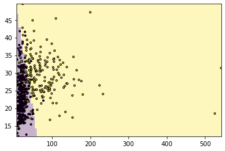

```python
x1 = df["area.se"]
x2 = df["texture.worst"]
y = df.diagnosis == "M"
X = np.column_stack((x1, x2))
m = LogisticRegression(solver="lbfgs").fit(X, y)

ex1 = np.linspace(x1.min(), x1.max(), 100) # 30 elements
ex2 = np.linspace(x2.min(), x2.max(), 100)
xx1, xx2 = np.meshgrid(ex1, ex2)

g = np.column_stack((xx1.ravel(), xx2.ravel()))

hatY = m.predict(g).reshape(100, 100)

_ = plt.imshow(hatY, extent=(x1.min(), x1.max(), x2.min(), x2.max()), aspect="auto", interpolation='none', origin='lower', alpha=0.3)
_ = plt.scatter(x1, x2, c=y, edgecolor='k', s=8)
_ = plt.show()
```

### 1. (12pt) Pick features texture.mean and concpoints.mean and do the following:

#### (a) Use these two to model diagnosis with k-NN where k = 7 using original features (i.e. not normalized features). Example code:

[output not shown]

```python
from sklearn.neighbors import KNeighborsClassifier
```

```python
x1 = df["texture.mean"]
x2 = df["concpoints.mean"]
X = np.column_stack((x1, x2))
y = df.diagnosis == "M"
```

```python
m = KNeighborsClassifier(7, metric = "euclidean")
_ = m.fit(X,y)
m.score(X,y)
```

```
0.81195079086116
```

#### (b) (6pt) Plot the corresponding decision boundary (use at least 100 × 100 matrix). Explain why do you see apparently arbitrary stripes on the image (vertical stripes in case you put texture on x-axis).

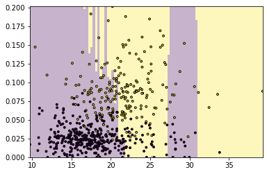

```python
ex1 = np.linspace(x1.min(), x1.max(), 100) # 30 elements
ex2 = np.linspace(x2.min(), x2.max(), 100)
xx1, xx2 = np.meshgrid(ex1, ex2)
# meshgrid creates two 30x30 matrices
g = np.column_stack((xx1.ravel(), xx2.ravel()))
# we create the design matrix by stacking the xx1, xx2
# after unraveling those into columns
# predict on the grid
hatY = m.predict(g).reshape(100, 100)
# imshow wants a matrix, so we reshape the predicted
# vector into one
_ = plt.imshow(hatY, extent=(x1.min(), x1.max(), x2.min(), x2.max()), aspect="auto", interpolation="none", origin="lower", alpha=0.3)
_ = plt.scatter(x1, x2, c=y, edgecolor="k", s=8)
_ = plt.show()
```

These stripes just shows the colors indicates where we have more purple or yellow out of k closes neighbors of data around the predicted values.

#### (c) (2pt) Cross-validate your prediction accuracy.

```python
from sklearn.model_selection import cross_val_score
```

```python
cv = cross_val_score(m, X, y, cv=10)
cv.mean()
```

```
0.7114974937343359
```

### 2. (5pt) Now normalize these two features and repeat the previous steps.

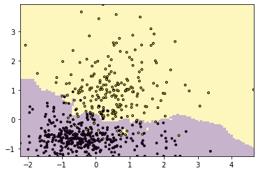

```python
Xn = np.empty_like(X)
for i in range(X.shape[1]):
    Xn[:,i] = (X[:,i] - X[:,i].mean())/X[:,i].std()

m = KNeighborsClassifier(7, metric = "euclidean")
_ = m.fit(Xn,y)
m.score(Xn,y)

x1 = (x1 - x1.mean())/x1.std()
x2 = (x2 - x2.mean())/x2.std()

ex1 = np.linspace(x1.min(), x1.max(), 100) # 30 elements
ex2 = np.linspace(x2.min(), x2.max(), 100)
xx1, xx2 = np.meshgrid(ex1, ex2)
# meshgrid creates two 30x30 matrices
g = np.column_stack((xx1.ravel(), xx2.ravel()))
# we create the design matrix by stacking the xx1, xx2
# after unraveling those into columns
# predict on the grid
hatY = m.predict(g).reshape(100, 100)
# imshow wants a matrix, so we reshape the predicted
# vector into one
_ = plt.imshow(hatY, extent=(x1.min(), x1.max(), x2.min(), x2.max()), aspect="auto", interpolation="none", origin="lower", alpha=0.3)
_ = plt.scatter(x1, x2, c=y, edgecolor="k", s=8)
_ = plt.show()
```

```python
cv = cross_val_score(m, Xn, y, cv=10)
cv.mean()
```

```
0.9208646616541353
```

### 3. (10pt) Explain why does the decision boundary plot look different now. Comment on the accuracy: was accuracy better with original features or normalized features?

The accuracy of the normalized features seems to be more accurate. It was originally 71% (non-normalized) and increased to 92% normalized).

### 4. (10pt) now use the original (non-normalized) features and repeat the process. However, this time use Mahalanobis distance.

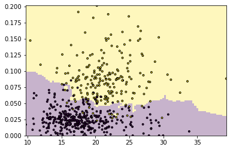

```python
x1 = df["texture.mean"]
x2 = df["concpoints.mean"]
X = np.column_stack((x1, x2))


Sigma = np.cov(X, rowvar=False)
m = KNeighborsClassifier(n_neighbors=7, metric="mahalanobis", metric_params={"V":Sigma})
_ = m.fit(X,y)
m.score(X,y)


ex1 = np.linspace(x1.min(), x1.max(), 100) # 30 elements
ex2 = np.linspace(x2.min(), x2.max(), 100)
xx1, xx2 = np.meshgrid(ex1, ex2)
# meshgrid creates two 30x30 matrices
g = np.column_stack((xx1.ravel(), xx2.ravel()))
# we create the design matrix by stacking the xx1, xx2
# after unraveling those into columns
# predict on the grid
hatY = m.predict(g).reshape(100, 100)
# imshow wants a matrix, so we reshape the predicted
# vector into one
_ = plt.imshow(hatY, extent=(x1.min(), x1.max(), x2.min(), x2.max()), aspect="auto", interpolation="none", origin="lower", alpha=0.3)
_ = plt.scatter(x1, x2, c=y, edgecolor="k", s=8)
_ = plt.show()
```

### 5. (7pt) Repeat all these steps with a few other sets of two features and a few other k-s of your choice.

```python
#function that does everything
def metrics(x, metric, k):
    if(metric == "mahalanobis"):
        Sigma = np.cov(x, rowvar=False)
        m = KNeighborsClassifier(n_neighbors=k,
            metric="mahalanobis",
            metric_params={"V":Sigma})
    else:
        m = KNeighborsClassifier(k, metric = metric)
    _ = m.fit(x,y)
    m.score(x,y)
    cv = cross_val_score(m, x, y, cv=10)
    print("k:",k)
    print("accuracy:" , np.mean(cv))
    ex1 = np.linspace(x1.min(), x1.max(), 100) # 30 elements
    ex2 = np.linspace(x2.min(), x2.max(), 100)
    xx1, xx2 = np.meshgrid(ex1, ex2)
    # meshgrid creates two 30x30 matrices
    g = np.column_stack((xx1.ravel(), xx2.ravel()))
    # we create the design matrix by stacking the xx1, xx2
    # after unraveling those into columns
    # predict on the grid
    hatY = m.predict(g).reshape(100, 100)
    # imshow wants a matrix, so we reshape the predicted
    # vector into one
    _ = plt.imshow(hatY, extent=(x1.min(), x1.max(), x2.min(), x2.max()), aspect="auto", interpolation="none", origin="lower", alpha=0.3)
    _ = plt.scatter(x1, x2, c=y, edgecolor="k", s=8)
    _ = plt.show()
```

```
k: 100
accuracy: 0.882236842105263
```

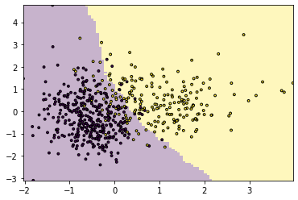

```python
x1 = df["radius.mean"]
x2 = df["smoothness.mean"]
x1 = (x1 - x1.mean())/x1.std()
x2 = (x2 - x2.mean())/x2.std()
X = np.column_stack((x1, x2))
Xn = np.empty_like(X)
for i in range(X.shape[1]):
    Xn[:,i] = (X[:,i] - X[:,i].mean())/X[:,i].std()
metrics(Xn, "euclidean", 100)
```

```
k: 100
accuracy: 0.8841165413533835
```

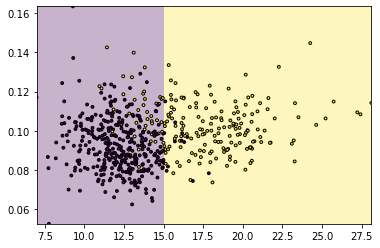

```python
x1 = df["radius.mean"]
x2 = df["smoothness.mean"]
X = np.column_stack((x1, x2))

metrics(X, "euclidean", 100)
```

```
k: 5
accuracy: 0.8929511278195488
```

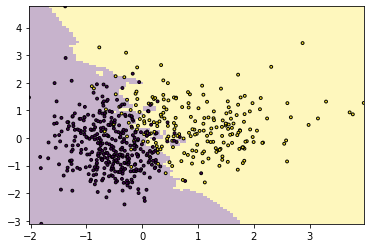

```python
x1 = (x1 - x1.mean())/x1.std()
x2 = (x2 - x2.mean())/x2.std()
X = np.column_stack((x1, x2))
metrics(Xn, "euclidean", 5)
```

```
k: 5
accuracy: 0.8876253132832079
```

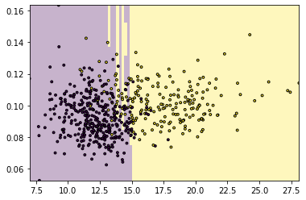

```python
x1 = df["radius.mean"]
x2 = df["smoothness.mean"]
X = np.column_stack((x1, x2))
metrics(X, "euclidean", 5)
```

```
k: 100
accuracy: 0.8769736842105263
```

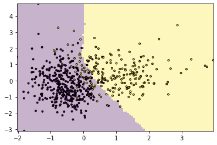

```python
x1 = (x1 - x1.mean())/x1.std()
x2 = (x2 - x2.mean())/x2.std()
X = np.column_stack((x1, x2))
metrics(Xn, "mahalanobis", 100)
```

```
k: 100
accuracy: 0.8769736842105263
```

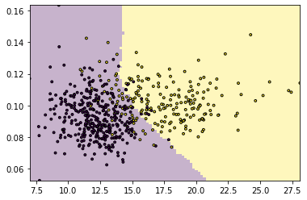

```python
x1 = df["radius.mean"]
x2 = df["smoothness.mean"]
X = np.column_stack((x1, x2))
metrics(X, "mahalanobis", 100)
```

```
k: 5
accuracy: 0.8982142857142857
```

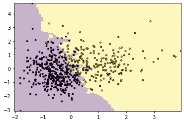

```python
x1 = (x1 - x1.mean())/x1.std()
x2 = (x2 - x2.mean())/x2.std()
X = np.column_stack((x1, x2))
metrics(Xn, "mahalanobis", 5)
```

```
k: 5
accuracy: 0.8982142857142857
```

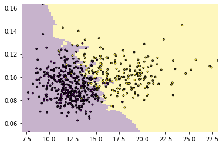

```python
x1 = df["radius.mean"]
x2 = df["smoothness.mean"]
X = np.column_stack((x1, x2))
metrics(X, "mahalanobis", 5)
```

### 6. (10pt) Describe your observations. How well do original/normalized/Mahalanobis-transformed features work? Does it depend on the features? Does the visual impression from images align with the cross-validation results?

Normalized features seems to match the graphs of the Mahalanobis-transformed features. I think the visual impressions align with the cv-results. Although the images look pretty similar to each other, you can see that the images of those with 89% accuracy are a little more precise than those with 87% (in terms of the background color). It seems like the lower the $k$ value, the higher the accuracy.

# 2. Images: Reduce number of colors (40pt)

### 1. (8pt) Get a color image you like, load it as matrix, and display it using matplotlib. You may use the code along these lines:

```
import matplotlib.pyplot as plt
from matplotlib.image import imread
pixels = imread("img/impala.jpg")
ax = plt.subplot(1,1,1)
ax.set_aspect("equal")
_ = plt.imshow(pixels)
_ = plt.show()
```

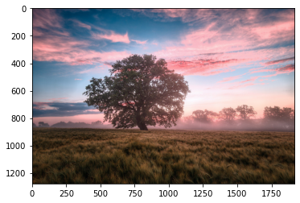

```python
import matplotlib.pyplot as plt
from matplotlib.image import imread
pixels = imread("../data/nature.jpeg")
ax = plt.subplot(1,1,1)
ax.set_aspect("equal")
_ = plt.imshow(pixels)
_ = plt.show()
```

```
(1278, 1920, 3)
(2453760, 3)
center color values:
 [[228.42042743 164.14843679 170.8563359 ]
 [ 55.20470143  40.57421709  25.72516113]
 [130.47404769 100.80207042 105.88908994]
 [113.82844652  78.82147919  62.48034746]
 [200.53233635 202.13305852 222.16343211]
 [192.95491513 141.44785364 148.08168238]
 [247.48516852 193.14543618 198.73327169]
 [ 22.18672168  74.96761314 108.75721728]
 [112.76977365 135.07123928 163.65695913]
 [ 81.69732007  58.9578301   42.52737224]
 [ 26.66353044  19.02300009   7.18807261]
 [ 65.15889045 107.50697626 140.91755233]
 [159.78100711 122.2452249  130.2261452 ]
 [247.49310795 227.10633911 229.89964341]
 [157.66464886 167.0567305  189.99325103]
 [ 85.22236776  81.52476405  98.97021297]]
```

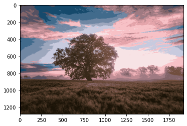

```python
print(pixels.shape)
# convert the ’pixels’ matrix into Nx3 (or Nx4) matrix
# where N is the number of pixels, and 3 or 4 is the number
# of color channels
# so each row is a pixel, and the row data is its color value
M = pixels.reshape((-1,pixels.shape[2]))
print(M.shape)

from sklearn.cluster import KMeans
m = KMeans(16).fit(M) # cluster the color values
cl = m.predict(M) # find the cluster id for each pixel
centers = m.cluster_centers_ # find the cluster centers (i.e. colors)
print("center color values:\n", centers)

compressed = centers[cl]/255 # normalize to between 0 and 1
compressed = compressed.reshape(pixels.shape)
# make it back to NxM array
ax = plt.subplot(1,1,1)
ax.set_aspect("equal")
_ = plt.imshow(compressed)
_ = plt.show()
```

### 2. (24pt) Get this code to work with your image and understand what it does. Explain:

#### (a) What does shape of pixels mean

Doing `pixels.shape` will give the size (i.e dimensions) of the picture. It gives the row, height, and color of the picture.

#### (b) What is matrix M? Why does it have 671040 rows and 3 columns in this example?

Matrix M includes the number of pixels and the number of color channels. In the example given, it just means that the pciture had a total of 671,040 pixels and 3 color channels

#### (c) What do cl values tell us? E.g. if cl[12345] = 2, what does it mean?

cl is the id for the corresponding cluster. cl[12345] = 2 would mean that cl at position 1234 has a cluster id of 2.

### 3. (8pt) Next repeat the above by reducing the number of colors to 2, and 4. Show the pictures!

##### Hint: make a function that takes the number of colors as an argument, then you don’t have to copy-paste your code that much.

```python
def colors(n):
    m = KMeans(n).fit(M) # cluster the color values
    cl = m.predict(M) # find the cluster id for each pixel
    centers = m.cluster_centers_ # find the cluster centers (i.e. colors)
    print("center color values:\n", centers)

    compressed = centers[cl]/255 # normalize to between 0 and 1
    compressed = compressed.reshape(pixels.shape)
    # make it back to NxM array
    ax = plt.subplot(1,1,1)
    ax.set_aspect("equal")
    _ = plt.imshow(compressed)
    _ = plt.show()
```

```
center color values:
 [[ 72.79846831  61.78856886  57.08631402]
 [202.31073492 172.63581292 183.56440307]]
```

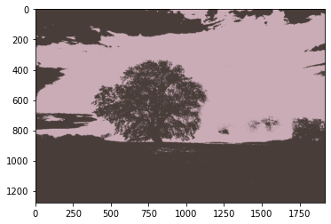

```python
colors(2)
```

```
center color values:
 [[ 93.97087084  87.73671838  94.83243527]
 [233.07884235 198.37741672 206.8358153 ]
 [ 54.55816418  40.4871265   26.42415182]
 [160.30545052 137.24925189 151.15529532]]
```

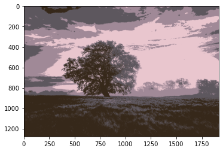

```python
colors(4)
```